# survival lecture 5

Steve Simon

May 27, 2018

This file does not need any special libraries other than the ones listed below. Many of the data sets in this program use data from Hosmer, Lemeshow, and May. I made one minor change, however, which was to force all the variable names to lower case.

```r
library(broom)
library(dplyr)
library(ggplot2)
library(magrittr)
library(survival)
library(tidyr)
```

## Exponential model

The exponential model is the simplest parametric model. The probability density function for the “standard” exponential distribution is

$f(t)=e^{-t}$

and the survival curve is

$S(t)=e^{-t}$.

The plot of the survival curve is

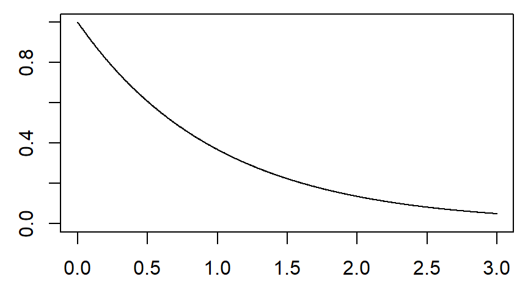

```r
par(mar=c(2.6, 2.6, 0.6, 0.6))
t <- seq(0, 3, length=1000)
plot(t, exp(-t), type="l", ylim=c(0,1))
```

You can include a rate parameter, $\lambda$, to create a density,

$f(t; \lambda)=\lambda e^{-\lambda t}$

and the survival curve is

$S(t; \lambda)=e^{-\lambda t}$

There is an equivalent form using a scale parameter, $\theta$,

$f(t; \theta) = \frac{1}{\theta} e^{-t/\theta}$.

$S(t; \theta) = e^{-t/\theta}$

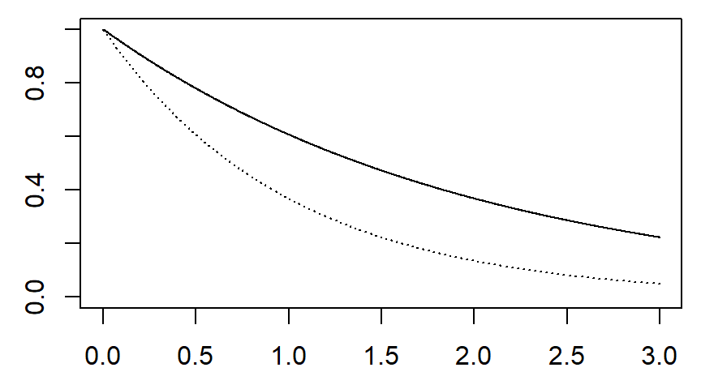

```r
par(mar=c(2.6, 2.6, 0.6, 0.6))
theta <- 2
plot(t, exp(-t/theta), type="l", ylim=c(0,1))
lines(t, exp(-t), lty="dotted")
```

If theta is larger than 1, the effect is to stretch out the exponential and slow down time.

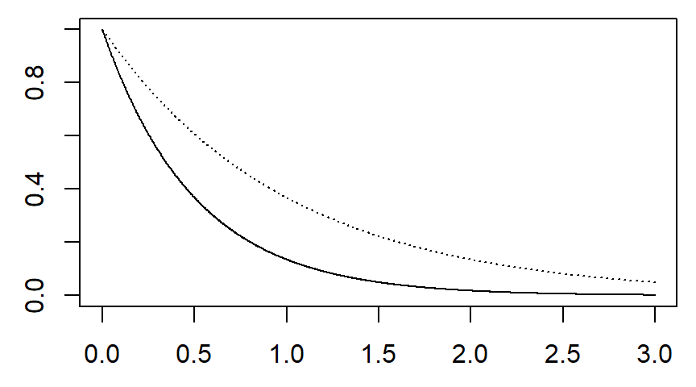

```r
par(mar=c(2.6, 2.6, 0.6, 0.6))
theta <- 0.5
plot(t, exp(-t/theta), type="l", ylim=c(0,1))
lines(t, exp(-t), lty="dotted")
```

The accelerated time model replaces $\theta$ with

$e^{(\beta_0+\beta_1 X)}$

This produces the survival curve

$S(t, X, \beta_0, \beta_1)=e^{-t/e^{(\beta_0+\beta_1 X)}}$

The values of $\beta_0$ and $\beta_1$ will end up stretching or shrinking the time scale.

The pth percentile of the accelerated time model is

$-ln(1-p) e^{\beta_0+\beta_1 X}$

and the ratio of two percentiles, one with X=$X_1$ and the other with X=$X_2$ is

$\frac{-ln(1-p) e^{\beta_0+\beta_1 X_1}} {-ln(1-p) e^{\beta_0+\beta_1 X_2}} = e^{\beta_1 (X_1-X_2)}$

If $X_1$ is one unit larger than $X_2$, this reduces to $e^{\beta_1}$.

This may look quite different than the model we used for Kaplan-Meier curves and the Cox proportional hazards model, but it actually is not. The hazard function is

$h(t, x, \beta_0, \beta_1)=e^{-(\beta_0+\beta_1 x)}$.

Notice that the hazard is constant with respect to t. The baseline hazard, the hazard when X=0 is

$h_0(t)=e^{-\beta_0}$

The hazard ratio for a subject with $x=x_1$ compared to a subject with $x=x_2$ is

$e^{-\beta_1 (x_1-x_2)}$

## Weibull model

The standard Weibull distribution has a density

$f(t, k)=k t^{k-1} e^{-t^k}$

and a survival function

$S(t, k)=e^{-t^\gamma}$.

You can add a scale parameter, $\theta$, to get

$f(t, k, \theta) = \frac {k} {\theta} \left( \frac {t} {\theta} \right)^{k-1} e^{-\left( \frac {t} {\theta} \right)^k}$

and a survival function

$S(t, k, \theta)=e^{-\left(\frac{t}{\theta}\right)^k}$.

The value of k controls whether the Weibull distribution has an increasing hazard (k>1), constant hazard (k=1), or decreasing hazard (k<1).

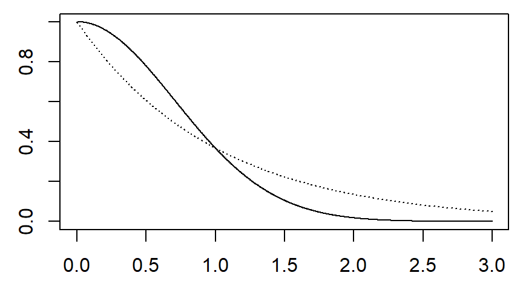

```r
par(mar=c(2.6, 2.6, 0.6, 0.6))
plot(t, 1-pweibull(t, shape=2), type="l", ylim=c(0,1))
lines(t, 1-pweibull(t, shape=1), lty="dotted")
```

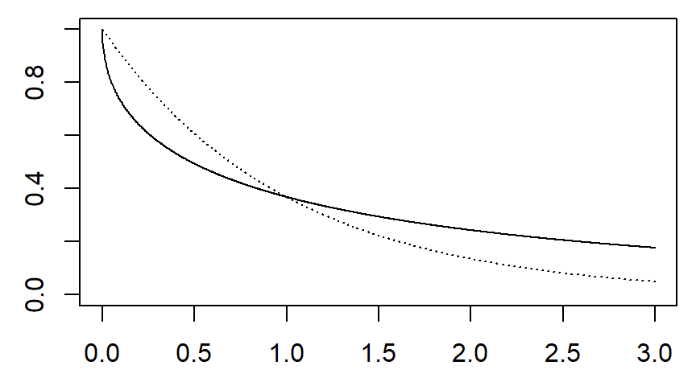

```r
plot(t, 1-pweibull(t, shape=0.5), type="l", ylim=c(0,1))
lines(t, 1-pweibull(t, shape=1), lty="dotted")
```

The scale parameter, $\theta$, will stretch or squeeze the survival curve along the time axis.

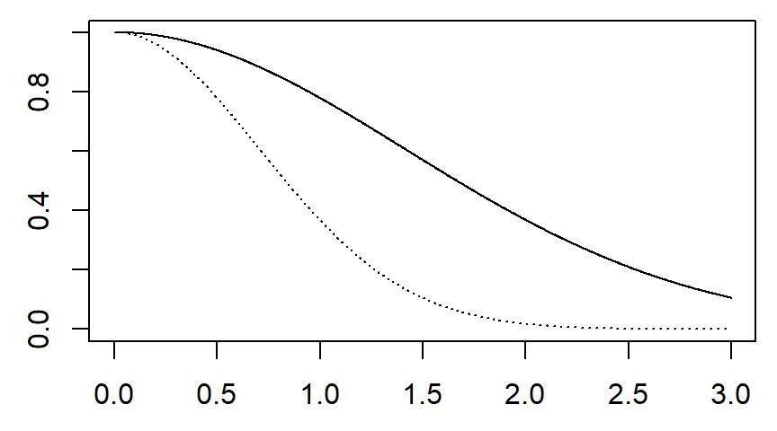

```r
par(mar=c(2.6, 2.6, 0.6, 0.6))
plot(t, 1-pweibull(t, shape=2, scale=2), type="l", ylim=c(0,1))
lines(t, 1-pweibull(t, shape=2, scale=1), lty="dotted")
```

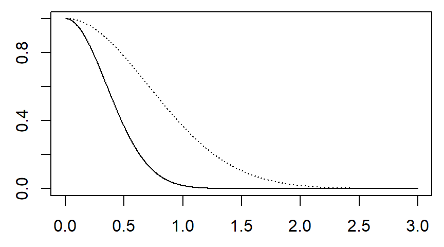

```r
plot(t, 1-pweibull(t, shape=2, scale=0.5), type="l", ylim=c(0,1))
lines(t, 1-pweibull(t, shape=2, scale=1), lty="dotted")
```

You can fit an accelerated time model for the Weibull distribution as well.

$S(t, k, X, \beta_0, \beta_1) = e^{-\left( \frac {t} {e^{\beta_0 + \beta_1 x}} \right)^k}$.

```r
r_response <- residuals(weibull_model, type="response")
r_deviance <- residuals(weibull_model, type="deviance")
r_dfbeta <- residuals(weibull_model, type="dfbeta")
r_dfbetas <- residuals(weibull_model, type="dfbetas")
r_working <- residuals(weibull_model, type="working")
r_ldcase <- residuals(weibull_model, type="ldcase")
r_ldresp <- residuals(weibull_model, type="ldresp")

head(r_response)
```

```
##           1           2           3           4           5           6
## -22.7899028  -2.4738004  -0.6887593  -2.9255007  -5.9503052   0.2813752
```

```r
head(r_deviance)
```

```
##           1           2           3           4           5           6
## -3.09144411 -0.84335769 -0.07788209 -1.49359541 -0.72390524  0.04102477
```

```r
head(r_dfbeta)
```

```
##   (Intercept) genderFemale           age           bmi genderFemale:age
## 1  0.22226265   0.06661507 -0.0013986288 -0.0049823154    -0.0005680821
## 2 -0.03671421   0.21429465  0.0003430414  0.0003199946    -0.0032844712
## 3 -0.03464561   0.05665129  0.0007012839 -0.0011235344    -0.0006543071
## 4 -0.10859463   0.01304833 -0.0002780161  0.0052087247    -0.0008291636
## 5  0.15460792   0.04744147 -0.0006355796 -0.0054229497    -0.0002273315
## 6 -0.05032145   0.04914707  0.0008103236 -0.0006829290    -0.0005746106
##     Log(scale)
## 1  0.057547853
## 2 -0.005722546
## 3 -0.015781637
## 4  0.011397753
## 5 -0.012281865
## 6 -0.015296395
```

```r
head(r_dfbetas)
```

```
##          [,1]        [,2]        [,3]         [,4]         [,5]
## 1  0.10857929 0.029155351 -0.06780320 -0.107202973 -0.018673541
## 2 -0.01793555 0.093790120  0.01663008  0.006885227 -0.107964510
## 3 -0.01692500 0.024794513  0.03399708 -0.024174749 -0.021507861
## 4 -0.05305043 0.005710848 -0.01347776  0.112074553 -0.027255604
## 5  0.07552874 0.020763660 -0.03081185 -0.116683966 -0.007472659
## 6 -0.02458293 0.021510148  0.03928314 -0.014694377 -0.018888138
##          [,6]
## 1  0.46328173
## 2 -0.04606863
## 3 -0.12704808
## 4  0.09175617
## 5 -0.09887360
## 6 -0.12314170
```

```r
head(r_working)
```

```
##             1             2             3             4             5
## -402.51914600   -2.08703718   -0.10286459   -7.79344774   -1.59985000
##             6
##    0.05002375
```

```r
head(r_ldcase)
```

```
##          1          2          3          4          5          6
## 0.29367550 0.03913177 0.01641203 0.05845173 0.03413614 0.01527342
```

```r
head(r_ldresp)
```

```
##          1          2          3          4          5          6
## 0.01579146 0.02884622 0.04080277 0.02138161 0.02295168 0.06974278
```

```r
p_response <- predict(weibull_model, type="response")
p_linear <- predict(weibull_model, type="linear")
p_terms <- predict(weibull_model, type="terms")

head(p_response)
```

```
## [1] 22.806330  3.497757  7.317096  3.193810  9.249415  5.372287
```

```r
head(p_linear)
```

```
## [1] 3.127038 1.252122 1.990214 1.161215 2.224560 1.681254
```

```r
exp(head(p_linear))
```

```
## [1] 22.806330  3.497757  7.317096  3.193810  9.249415  5.372287
```

```r
head(p_terms)
```

```
##      gender        age         bmi gender:age
## 1  1.641308  0.2078059  0.45825044  -1.524405
## 2 -3.048144 -1.2628203 -0.46216226   3.681169
## 3  1.641308 -0.5594774  0.08870909  -1.524405
## 4 -3.048144 -0.8152384 -0.58657155   3.267090
## 5  1.641308 -0.6234176  0.38699618  -1.524405
## 6 -3.048144 -0.8791787 -0.06174648   3.326244
```

```r
term_totals <- apply(p_terms, 1, sum)
head(term_totals)
```

```
##          1          2          3          4          5          6
##  0.7829593 -1.0919570 -0.3538653 -1.1828642 -0.1195184 -0.6628251
```

The hazard function for the Weibull distribution is

$h(t, k) = k t^{k-1}$

Save everything for possible later re-use.

```r
save.image("~/survival-models/bin/survival-lecture-5-supplement.RData")
```